```python
import pandas as pd
import matplotlib.pyplot as plt
from scipy import stats
import numpy as np
#this sets the size of th eplot to something useful
plt.rcParams["figure.figsize"] = (15,10)
```

```python
# say I choose my sigma to be 5.15.
mu, sigma, step = 0,5.15, int(1e6)
bkgd = stats.norm.rvs(loc = mu, scale = sigma, size = step)
signal = stats.uniform.rvs(loc = 0, scale = 20, size = step)
```

# 1

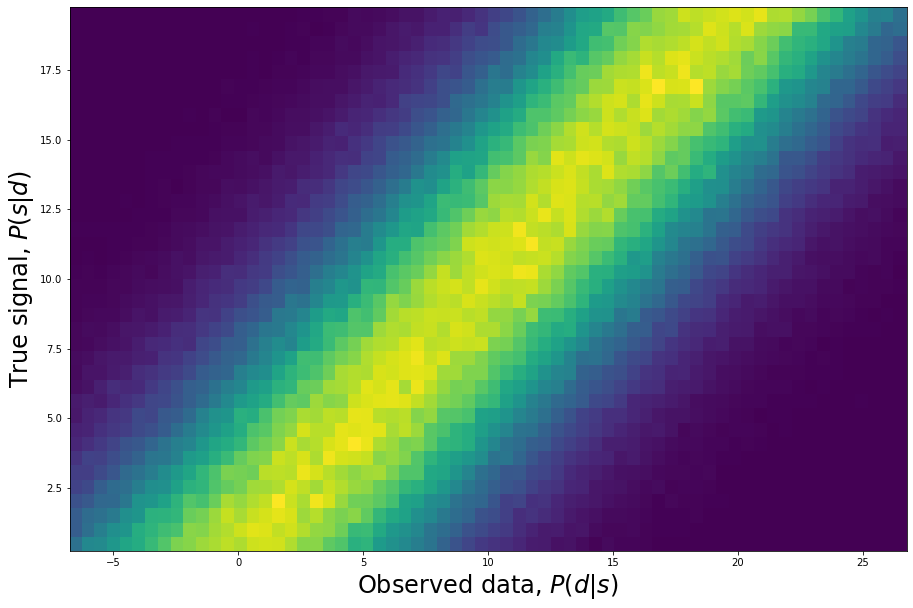

```python
# everything is the same as the code on canvas
data = bkgd + signal

signaledges = np.linspace(0,20,40)
dataedges = np.linspace(-7,27,68)

Psd, temp, temp1= np.histogram2d(data,signal, bins=[dataedges,signaledges], density=True)

datacenters = (dataedges[:-1] + dataedges[1:]) / 2
signalcenters = (signaledges[:-1] + signaledges[1:]) / 2
plt.pcolormesh(datacenters,signalcenters,Psd.T)
plt.ylabel('True signal, $P(s|d)$', fontsize = 24)
plt.xlabel('Observed data, $P(d|s)$', fontsize = 24)
#This should get you a plot like below.
```

```python
def prob_finder (input):
    prob = Psd[:,int(input/2)]
    reciprocal = 1 / np.sum(prob)
    prob = prob * reciprocal
    return prob

def plot_helper(cut,input, ifx):
    if(ifx): prob = prob_finder(Psd.shape[1])
    else: prob = prob_finder(Psd.shape[0])

    fig,ax = plt.subplots(1,2)
    ax[0].pcolormesh(datacenters,signalcenters,Psd.T)
    if(ifx):
        ax[0].plot(temp[1:],np.repeat([cut],len(temp[1:])),'p--')
    else:
        ax[0].plot(np.repeat([cut],len(temp1[1:])), temp1[1:],'p--')

    ax[0].set_ylabel('True signal, $P(s|d)$', fontsize = 24)
    ax[0].set_xlabel('Observed data, $P(d|s)$', fontsize = 24)
    ax[1].set_yscale('log')
    ax[1].step(dataedges[1:], prob)
    ax[1].set_xlabel('Signal')
    ax[1].set_ylabel('Probability')
    plt.show()
```

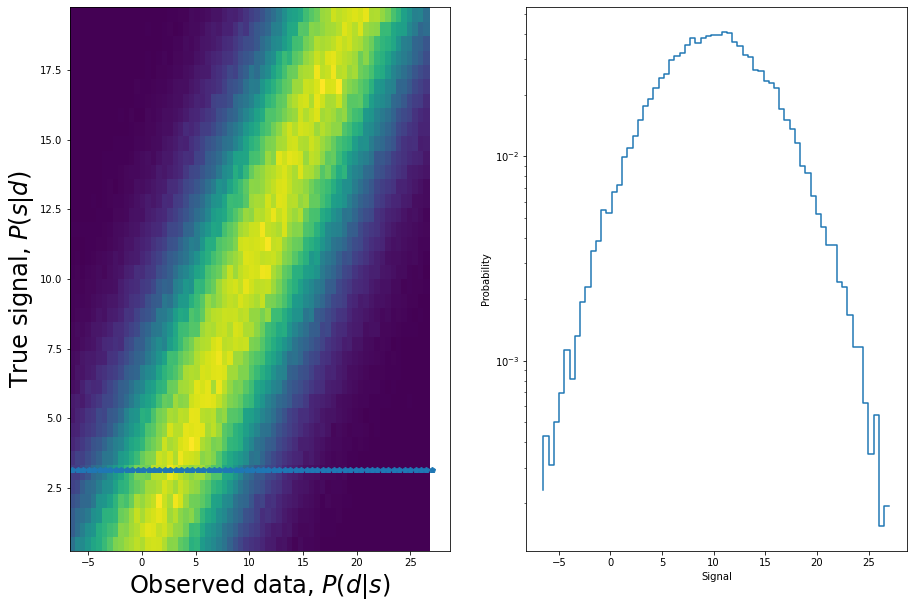

```python
#I choose y = 3.14159 to be the place where I explore.
plot_helper(3.14159,Psd.shape[1],True)
```

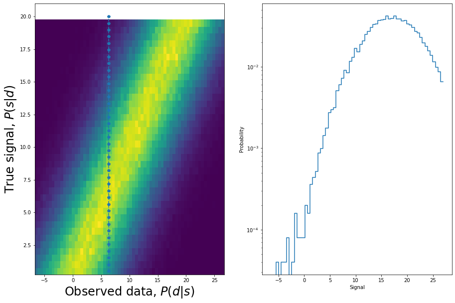

```python
#I chosee x to be 6.29318 to explore
plot_helper(3.14159*2, Psd.shape[0], False)
```

# Problem 2

repeat with non-zero bkgd

```python
# change mu to be non-zero
mu, sigma, step = 5,5.15, int(1e6)
bkgd = stats.norm.rvs(loc = mu, scale = sigma, size = step)
signal = stats.uniform.rvs(loc = 0, scale = 20, size = step)
```

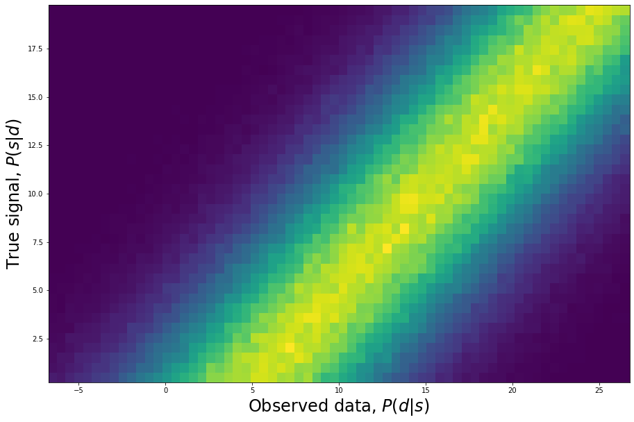

```python
# everything is the same as the code on canvas
data = bkgd + signal

signaledges = np.linspace(0,20,40)
dataedges = np.linspace(-7,27,68)

Psd, temp, temp1= np.histogram2d(data,signal, bins=[dataedges,signaledges], density=True)

datacenters = (dataedges[:-1] + dataedges[1:]) / 2
signalcenters = (signaledges[:-1] + signaledges[1:]) / 2
plt.pcolormesh(datacenters,signalcenters,Psd.T)
plt.ylabel('True signal, $P(s|d)$', fontsize = 24)
plt.xlabel('Observed data, $P(d|s)$', fontsize = 24)
#This should get you a plot like below.
```

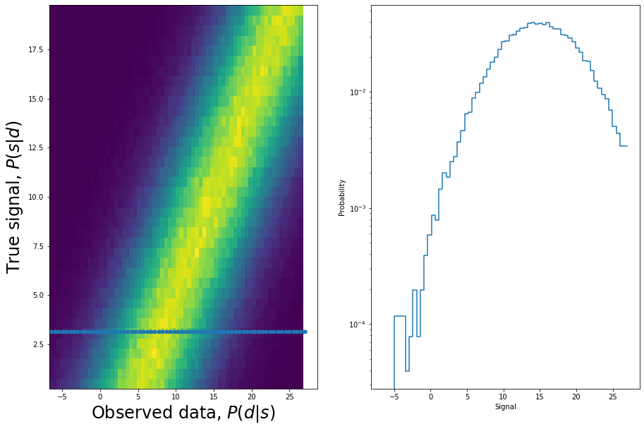

```python
plot_helper(3.14159, Psd.shape[1], True)
```

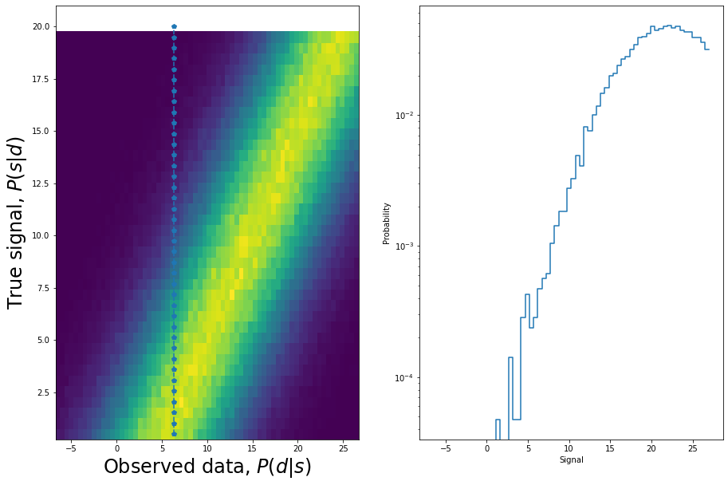

```python
plot_helper(6.28318, Psd.shape[0], False)
```

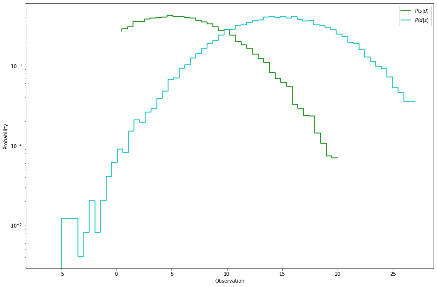

```python
plt.step(temp1[1:], Psd[int(Psd.shape[0]/2),:],color = 'g' ,label='$P(s|d)$')
plt.step(temp[1:], Psd[:,int(Psd.shape[1]/2)], color='c', label="$P(d|s)$")
plt.ylabel('Probability')
plt.xlabel('Observation')
plt.legend()
plt.yscale('log')
```

In Bayesian statistics, the posterior probability of a random event or an uncertain proposition is the conditional probability that is assigned[clarification needed] after the relevant evidence or background is taken into account. "Posterior", in this context, means after taking into account the relevant evidence related to the particular case being examined.

In statistics, the likelihood function (often simply called the likelihood) measures the goodness of fit of a statistical model to a sample of data for given values of the unknown parameters. It is formed from the joint probability distribution of the sample, but viewed and used as a function of the parameters only, thus treating the random variables as fixed at the observed values.[a]

They are simply two different things !

Also, for any mu that is not equal to zero, they should be different.

Source:https://en.wikipedia.org/wiki/Likelihood_function

Source:https://en.wikipedia.org/wiki/Posterior_probability